# Question 1.

## Demonstration

Below, we will see how the script works in action. I will use the script to create a pandas dataframe containing **200 HDB flat resale transactions** that took place in **March 2016.**

```python
df = download_data(selection = "pandas", month = "2016-03", limit = 200, offset = 0)

print("\n ---dataframe preview---\n")
display(df.head(3))

print("\n ---dataframe shape---\n")
display(df.shape)

print("\n ---dataframe information---\n")
display(df.info())
```

```
This code contains information from the dataset 'Resale Flat Prices' accessed on 20 January 2019 from www.data.gov.sg. This information is made available under the terms of the Singapore Open Data Licence version 1.0.
-----------------------------------------------------------------------------
Status code of 200 was obtained; Connection was successfully established.
-----------------------------------------------------------------------------

 ---dataframe preview---
```

|  | block | flat_model | flat_type | floor_area_sqm | lease_commence_date | month | rank month | remaining_lease | resale_price | storey_range | street_name | town |
| --- | --- | --- | --- | --- | --- | --- | --- | --- | --- | --- | --- | --- |
| 0 | 605 | Multi Generation | MULTI-GENERATION | 163 | 1988-01-01 | 2016-03-01 | 0.090167 | 70 | 688000 | 01 TO 03 | YISHUN ST 61 | YISHUN |
| 1 | 724 | Apartment | EXECUTIVE | 145 | 1986-01-01 | 2016-03-01 | 0.090167 | 69 | 650000 | 10 TO 12 | YISHUN ST 71 | YISHUN |
| 2 | 877 | Maisonette | EXECUTIVE | 145 | 1987-01-01 | 2016-03-01 | 0.090167 | 70 | 648000 | 04 TO 06 | YISHUN ST 81 | YISHUN |

```
 ---dataframe shape---
```

```
(200, 12)
```

```
 ---dataframe information---

<class 'pandas.core.frame.DataFrame'>
Int64Index: 200 entries, 0 to 199
Data columns (total 12 columns):
block                  200 non-null object
flat_model             200 non-null object
flat_type              200 non-null object
floor_area_sqm         200 non-null int64
lease_commence_date    200 non-null datetime64[ns]
month                  200 non-null datetime64[ns]
rank month             200 non-null float64
remaining_lease        200 non-null int64
resale_price           200 non-null int64
storey_range           200 non-null object
street_name            200 non-null object
town                   200 non-null object
dtypes: datetime64[ns](2), float64(1), int64(3), object(6)
memory usage: 20.3+ KB
```

```
None
```

This script can be conveniently used in a broader data science project. Below, I have provided an example of a downstream exploratory step that can be undertaken after fetching this data. In this step, I create a pairplot that showcases relationships among the various features of the data.

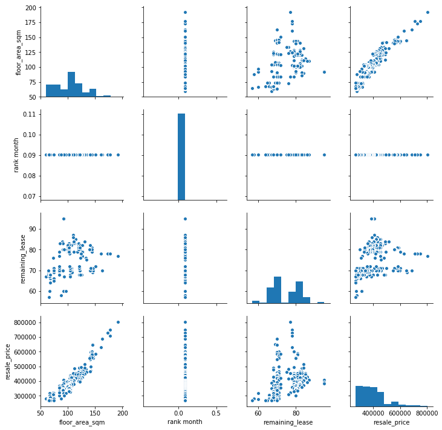

```python
import matplotlib.pyplot as plt
import seaborn as sns
%matplotlib inline

sns.pairplot(df)
```